# Neural Networks Application: Recurrent Neural Networks (R)

Daniel S. Hain (dsh@business.aau.dk)

Updated November 26, 2020

```r
library(tidyverse)
library(magrittr)

library(keras)
```

# RNN basics

## Loops

To make these notions absolutely unambiguous, let’s write a naive `R` implementation of the forward pass of the simple RNN.

```r
# We define a function that produces a "random" array
random_array <- function(dim) {
  array(runif(prod(dim)), dim = dim)
}
```

```r
# We define some constants as arguments for the functions to come
timesteps <- 100 # Number of timesteps in the input sequence
input_features <- 32 # Dimensionality of the input feature space
output_features <- 64 # Dimensionality of the output feature space
```

```r
# We create the initial inputs
inputs <- random_array(dim = c(timesteps, input_features)) # Input data: random noise for the sake of the example
state_t <- rep_len(0, length = c(output_features)) # Initial state t: an all-zero vector
```

```r
# We create some random matrices for W, U, b
W <- random_array(dim = c(output_features, input_features)) # Creates random weight matrices: W
U <- random_array(dim = c(output_features, output_features)) # Creates random weight matrices: U
b <- random_array(dim = c(output_features, 1)) # Creates random weight matrices: b
```

```r
# We create an empty array for the output sequence
output_sequence <- array(0, dim = c(timesteps, output_features))
```

```r
dim(output_sequence)
```

```
[1] 100  64
```

```r
head(output_sequence[,1:5])
```

```
     [,1] [,2] [,3] [,4] [,5]
[1,]    0    0    0    0    0
[2,]    0    0    0    0    0
[3,]    0    0    0    0    0
[4,]    0    0    0    0    0
[5,]    0    0    0    0    0
[6,]    0    0    0    0    0
```

So, we just made up an random `inputs` array, lets take a little look:

```r
dim(inputs)
```

```
[1] 100  32
```

```r
head(inputs[,1:5])
```

```
          [,1]       [,2]      [,3]       [,4]      [,5]
[1,] 0.4374455 0.65958703 0.8908022 0.30223137 0.1398738
[2,] 0.4993365 0.04578802 0.6532554 0.87700350 0.9450578
[3,] 0.8464301 0.60858042 0.3293128 0.99067676 0.8256690
[4,] 0.8522938 0.63519020 0.3309987 0.09233357 0.6345082
[5,] 0.5475497 0.60797047 0.4218896 0.34651074 0.6111947
[6,] 0.6299324 0.19615404 0.2303865 0.55745211 0.9669684
```

```r
dim(W)
```

```
[1] 64 32
```

```r
head(W[,1:5])
```

```
           [,1]      [,2]        [,3]      [,4]       [,5]
[1,] 0.05131798 0.4428372 0.047965156 0.9116978 0.05780573
[2,] 0.41738887 0.7932492 0.647385459 0.9647217 0.46568377
[3,] 0.11388474 0.9096280 0.009517771 0.1819730 0.78334617
[4,] 0.31752881 0.7400719 0.889261930 0.1602679 0.80351720
[5,] 0.49609406 0.1952676 0.134865081 0.4120722 0.97223370
[6,] 0.29625469 0.9341890 0.563066539 0.1283034 0.63314607
```

All set up, lets run a loop, where we apply some activation function (here `tanh()`) on the weighted `input_t`, but we add the (in another way) weighted `state_t` (the lagged value of `input_t` $\rightarrow$ `input_t-1`).

**Note:** I use `tanh()` just as an example for whatever activation function you might want to apply to your inputs. `tanh()` (hyperbolic tangent) is popular for RNNs, since it squishes input values between a range of `[-1,1]`

```r
for (i in 1:nrow(inputs)) {
  input_t <- inputs[i,]                                                # input_t is a vector of shape (input_features)
  output_t <- tanh(as.numeric((W %*% input_t) + (U %*% state_t) + b))  # Combines the input with the current state (the previous output)
  output_sequence[i,] <- as.numeric(output_t)                          # Updates the result matrix
  state_t <- output_t                                                  # Updates the state of the network for the next timestep
}
```

```r
glimpse(output_sequence)
```

```
 num [1:100, 1:64] 1 1 1 1 1 ...
```

**Note:** In `U %*% state_t`, the `%*%` operator performs a real matrix multiplication (every element of `U` gets multiplied with every element of `state_t`), not the dotproduct (cell-wise multiplication), as `U * state_t` would.

Easy enough: in summary, an RNN is an neural network application of a `for()` (reuses values computed during the previous iteration of the loop), nothing more. Of course, there are many different RNNs fitting this definition that you could build—this example is one of the simplest RNN formulations. Anyhow, In case we would not have to train the weights, we are done by here.

RNNs are characterized by their step function, such as the following function in this case

```r
output_t <- tanh(as.numeric((W %*% input_t) + (U %*% state_t) + b))
```

```r
glimpse(output_t)
```

```
 num [1:64] 1 1 1 1 1 1 1 1 1 1 ...
```

So, that’s pretty much how to construct a recurrent layer “by hand”. Most probably you will never have to, but I like to believe it demystifies the whole process.Moving on…

## Recurrent Layers in `Keras`

The process you just naively implemented in `R` corresponds to an actual `Keras` layer: `layer_simple_rnn`

```r
layer_simple_rnn(units = 32)
```

Like all recurrent layers in `Keras`, `layer_simple_rnn` can be run in two different modes:

1. it can return either the full sequences of successive outputs for each timestep (a 3D tensor of shape `(batch_size, timesteps, output_features)`)
2. or only the last output for each input sequence (a 2D tensor of shape `(batch_size, output_features)`).

These two modes are controlled by the `return_sequences` constructor argument. Let’s look at an example that uses `layer_simple_rnn` and returns only the output at the last timestep:

```r
model <- keras_model_sequential() %>%
  layer_embedding(input_dim = 10000, output_dim = 32) %>% # About this type of layer, we talk later
  layer_simple_rnn(units = 32)
```

[output not shown]

```r
summary(model)
```

```
Model: "sequential"
______________________________________________________________________________________________________________
Layer (type)                                     Output Shape                                Param #
==============================================================================================================
embedding (Embedding)                            (None, None, 32)                            320000
______________________________________________________________________________________________________________
simple_rnn (SimpleRNN)                           (None, 32)                                  2080
==============================================================================================================
Total params: 322,080
Trainable params: 322,080
Non-trainable params: 0
______________________________________________________________________________________________________________
```

The following example in turn returns the full state sequence (`return_sequences = TRUE`):

```r
model_sequence <- keras_model_sequential() %>%
  layer_embedding(input_dim = 10000, output_dim = 32) %>%
  layer_simple_rnn(units = 32, return_sequences = TRUE)
```

```r
summary(model_sequence)
```

```
Model: "sequential_1"
______________________________________________________________________________________________________________
Layer (type)                                     Output Shape                                Param #
==============================================================================================================
embedding_1 (Embedding)                          (None, None, 32)                            320000
______________________________________________________________________________________________________________
simple_rnn_1 (SimpleRNN)                         (None, None, 32)                            2080
==============================================================================================================
Total params: 322,080
Trainable params: 322,080
Non-trainable params: 0
______________________________________________________________________________________________________________
```

It’s sometimes useful to stack several recurrent layers one after the other in order to increase the representational power of a network. In such a setup, you have to get all of the intermediate layers to return full sequences. More on that later.

```r
model_sequence_stacked <- keras_model_sequential() %>%
  layer_embedding(input_dim = 10000, output_dim = 32) %>%
  layer_simple_rnn(units = 32, return_sequences = TRUE) %>%
  layer_simple_rnn(units = 32, return_sequences = FALSE)
```

```r
summary(model_sequence_stacked)
```

```
Model: "sequential_2"
______________________________________________________________________________________________________________
Layer (type)                                     Output Shape                                Param #
==============================================================================================================
embedding_2 (Embedding)                          (None, None, 32)                            320000
______________________________________________________________________________________________________________
simple_rnn_3 (SimpleRNN)                         (None, None, 32)                            2080
______________________________________________________________________________________________________________
simple_rnn_2 (SimpleRNN)                         (None, 32)                                  2080
==============================================================================================================
Total params: 324,160
Trainable params: 324,160
Non-trainable params: 0
______________________________________________________________________________________________________________
```

# Recurrent Neural Networks (a text example)

So, lets start applying a first RNN, and since you are already warmed up, we do it with text data. It is not hard to see why for making sense of text data, sequential models would be a good idea.

## The IMDB dataset

You’ll work with the IMDB dataset: a set of 50,000 highly polarized movie reviews from the Internet Movie Database, labeled by sentiment (positive/negative). They’re split into 25,000 reviews for training and 25,000 reviews for testing, each set consisting of 50% negative and 50% positive reviews. Read more details [here](https://keras.io/datasets/#imdb-movie-reviews-sentiment-classification). in case you are interested.

Just like the MNIST dataset, the IMDB dataset comes packaged with `Keras`, and is already neathly preprocessed. Each review is encoded as a **sequence** of word indexes (integers), where each integer stands for a specific word in a dictionary. For convenience, words are indexed by overall frequency in the dataset, so that for instance the integer `3` encodes the 3rd most frequent word in the data. This allows for quick filtering operations such as: “only consider the top `10,000` most common words, but eliminate the top `20` most common words” (Note: `0` is the encoding for unknown words).

### Load the data

```r
imdb <- dataset_imdb(num_words = 10000)
```

```r
#c(c(train_data, train_labels), c(test_data, test_labels)) %<-% imdb
```

**Note:** The datasets built into Keras are all nested lists of training and test data. Here, we use the multi-assignment operator `%<-%` from the `zeallot` package to unpack the list into a set of distinct variables. This is only a convenience function, and could equally be written as follows:

```r
train_data <- imdb$train$x
train_labels <- imdb$train$y

test_data <- imdb$test$x
test_labels <- imdb$test$y
```

The argument `num_words = 10000` means we keep only the top 10,000 most frequently occurring words in the training data. Rare words will be discarded. This allows you to work with vector data of a manageable size.

The variables `train_data` and `test_data` are lists of reviews; each review is a list of word indices (encoding a sequence of words). `train_labels` and `test_labels` are lists of 0s and 1s, where `0` stands for negative and `1` stands for positive:

```r
glimpse(train_labels[1:5])
```

```
 int [1:5] 1 0 0 1 0
```

```r
glimpse(train_data[1:5])
```

```
List of 5
 $ : int [1:218] 1 14 22 16 43 530 973 1622 1385 65 ...
 $ : int [1:189] 1 194 1153 194 8255 78 228 5 6 1463 ...
 $ : int [1:141] 1 14 47 8 30 31 7 4 249 108 ...
 $ : int [1:550] 1 4 2 2 33 2804 4 2040 432 111 ...
 $ : int [1:147] 1 249 1323 7 61 113 10 10 13 1637 ...
```

Because you’re restricting yourself to the top 10,000 most frequent words, no word index will exceed 10,000:

```r
train_data %>% map_int(max) %>% max()
```

```
[1] 9999
```

Sidenote: Notice that all words are not appearing anymore as strings, but as a numeric index. This is very pratical to do as preprocesing of text data before using them for ML workflows. However, we cannot read the reviews anymore manyally. Only for fun, here’s how you can quickly decode one of these reviews back to English words:

```r
word_index <- dataset_imdb_word_index() # word_index is a named list mapping words to an integer index.
```

```r
word_index %>% head()
```

```r
word_index %<>% as_tibble() %>%
  pivot_longer(everything())
```

```r
word_index %>% head()
```

| name | value |
| --- | --- |
| fawn | 34701 |
| tsukino | 52006 |
| nunnery | 52007 |
| sonja | 16816 |
| vani | 63951 |
| woods | 1408 |

```r
review_words <- train_data[[1]] %>% as_tibble() %>%
  left_join(word_index, by = 'value')
```

```r
review_words %>% pull(name) %>% paste(collapse = ' ')
```

```
[1] "the as you with out themselves powerful lets loves their becomes reaching had journalist of lot from anyone to have after out atmosphere never more room and it so heart shows to years of every never going and help moments or of every chest visual movie except her was several of enough more with…
```

### Preprocessing

So, we have our data ready. However, we cannot can’t feed lists of integers (keep in mind, they are supposed to not represent numbers but words) into a neural network. You have to turn your lists into tensors. There are two ways to do that:

1. **One-hot encode** your lists to turn them into vectors of 0s and 1s. This would mean, for instance, turning the sequence `[3, 5]` into a 10,000-dimensional vector that would be all 0s except for indices `3` and `5`, which would be `1`. Then you could use as the first layer in your network a dense layer, capable of handling floating-point vector data.
2. **Pad** your lists so that they all have the same length, turn them into an integer tensor of shape `(samples, word_indices)`, and then use as the first layer in your network a layer capable of handling such integer tensors (the “embedding” layer, comming soon).

While the first approach sounds computationally very inefficient, it is also the most intuitive to operationalize in terms of data-munging. Let’s warm up with this first solution and vectorize the data, which we will do manually for maximum clarity.

```r
# Again, a small function that creates a 0-matrix, and replaces the corresponding words with 1.
vectorize_sequences <- function(sequences, dimension) {
  results <- matrix(0, nrow = length(sequences), ncol = dimension) # Creates an all-zero matrix of shape (length(sequences), dimension)
  for(i in 1:length(sequences)){
    results[i, sequences[[i]]] <- 1 # Sets specific indices of results[i] to 1s
  }
  return(results)
}
```

```r
x_train <- train_data %>% vectorize_sequences(dimension = 10000)
x_test <- test_data %>% vectorize_sequences(dimension = 10000)
```

Here’s what the samples look like now:

```r
str(x_train[1,])
```

```
 num [1:10000] 1 1 0 1 1 1 1 1 1 0 ...
```

**Hint:** The `keras` function `to_categorical()`, which does exactly the same more convenient when the data is in a dataframe shape.

We now only recode the outcomes as numerical.

```r
y_train <- as.numeric(train_labels)
y_test <- as.numeric(test_labels)
```

Now the data is ready to be fed into a neural network.

## A baseline feed-forward ANN

So far so good, let’s run a “normal” feed-forward ANN to predict the review sentiment. We do so, just to warm up and get a sense how good it performs. A little reminder, to build and run a `Keras` model, you need to:

1: Define the architecture (Layers, shape & activation) 2: Compile the model (choosing optimizer, loss function, and metric) 3: Run the model

### Model architecture

We use, like before, a simple feed forward architecture with an input layer of shape 10.000 (number of words in our review vector), 2 inetrmediate hidden layers with 16 units each, and an ouput layer with only 1 unit (since we perform a binary classification). For the hidden layers, we use the standard `relu` activation function, for the output we use `sigmoid`, as common for binary classification. Note that all architecture choices in this example are standard, but not necessarily informed by our data. Just a good rule-of-thumb starting point.

```r
model <- keras_model_sequential() %>%
  layer_dense(units = 16, activation = "relu", input_shape = c(10000)) %>%
  layer_dense(units = 16, activation = "relu") %>%
  layer_dense(units = 1, activation = "sigmoid")
```

```r
model %>% compile(
  optimizer = "adam",
  loss = "binary_crossentropy",
  metrics = "accuracy"
)
```

So, we are pretty much done. Due to the big fiorst layer, we have a lot of parameter, but otherwise nothing extraordinary happening yet.

```r
summary(model)
```

```
Model: "sequential_3"
______________________________________________________________________________________________________________
Layer (type)                                     Output Shape                                Param #
==============================================================================================================
dense_2 (Dense)                                  (None, 16)                                  160016
______________________________________________________________________________________________________________
dense_1 (Dense)                                  (None, 16)                                  272
______________________________________________________________________________________________________________
dense (Dense)                                    (None, 1)                                   17
==============================================================================================================
Total params: 160,305
Trainable params: 160,305
Non-trainable params: 0
______________________________________________________________________________________________________________
```

Lets run it!

```r
history_ann <- model %>% fit(
  x_train,
  y_train,
  epochs = 10,
  batch_size = 512,
  validation_split = 0.25
)
```

And lets take a look how the accuracy and loss developed over the epocs.

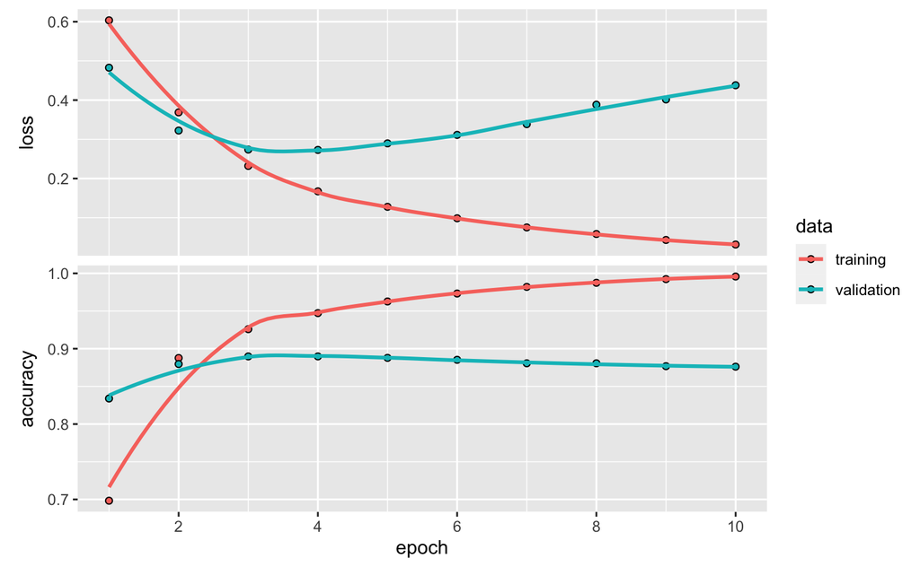

```r
plot(history_ann)
```

Ok, agaion we see that we are overfitting. While accuracy and loss as in most cases further increases during the epocs, we see after 3 epocs the metrics to decline on our validation data. At one point we have to deal with that, but not now.

Lets just sum up:

- We created a one-hot-encoding term-document matrix for the most 10.000 frequent terms used in Imdb reviews, and used that to predict if the review had a positive or negative sentiment.
- We did so by feeding this 10.000 dimensional vector as a 2d tensor of shape `(sample, features)` to a simple feed-forward network with pretty standard architecture
- We got an accuracy somewhere between 85-90% in the validation sample.

I would say, not too bad at all. However, represenmting a review as a 10.000 dimensional vector of one-hot encodings of word occurence appears pretty blunt. There must be something better, right?

## A Recurrent Neural Network Approach to text data in `Keras`

So, now that we tried a pretty naive model as baseline, lets move on.

### Preprocessing

In our first baseline model, we used a document-term matrix as inputs for training, with one-hot-encodings (= dummy variables) for the 10.000 most popular terms. This has a couple of disadvantages. Besides being a very large and sparse vector for every review, as a “bag-of-words”, it did not take the word-order (sequence) into account.

This time, we use a different approach, therefore also need a different input data-structure. We now use `pad_sequences()` to create a integer tensor of shape `(samples, word_indices)`. However, reviews vary in lenght, which is a problem since `Keras` reqieres the inputs to have the same shape across the whole sample. Therefore, we use the `maxlen = 500` argument, to restrict ourselves to the first 500 words in every review.

As a consequence, longer reviews will be cut at 500 words, and shorter reviews will be filled up with 0 values.

```r
x_train <- pad_sequences(train_data, maxlen = 500)
x_test <- pad_sequences(test_data, maxlen = 500)
```

Lets take a look:

```r
glimpse(x_train)
```

```
 int [1:25000, 1:500] 0 0 0 687 0 0 0 4 0 0 ...
```

Lets set up our model. as discussed, we will first use a `layer_embedding` to compress our initial one-hot-encoding vector of lenght 10.000 to a “meaning-vector” (=embedding) of the lower dimensionality of 32. We did not talk about that too much, but the next session will dig deeper into that. Just take it for now…

Then we add a `layer_simple_rnn` on top, and finally a `layer_dense` for the binary prediction of review sentiment.

```r
model_rnn <- keras_model_sequential() %>%
  layer_embedding(input_dim = 10000, output_dim = 32) %>%
  layer_simple_rnn(units = 32, activation = "tanh") %>%
  layer_dense(units = 1, activation = "sigmoid")
```

```r
summary(model_rnn)
```

```
Model: "sequential_4"
_________________________________________________________________________________________________
Layer (type)                               Output Shape                           Param #
=================================================================================================
embedding_3 (Embedding)                    (None, None, 32)                       320000
_________________________________________________________________________________________________
simple_rnn_4 (SimpleRNN)                   (None, 32)                             2080
_________________________________________________________________________________________________
dense_3 (Dense)                            (None, 1)                              33
=================================================================================================
Total params: 322,113
Trainable params: 322,113
Non-trainable params: 0
_________________________________________________________________________________________________
```

THe further parameters are quite conventional and by now well-known.

```r
model_rnn %>% compile(
  optimizer = "adam",
  loss = "binary_crossentropy",
  metrics = "accuracy"
)
```

And we already run the model:

```r
history_rnn <- model_rnn %>% fit(
  x_train, y_train,
  epochs = 10,
  batch_size = 128,
  validation_split = 0.25
)
```

Yes, I know, this one takes a while…

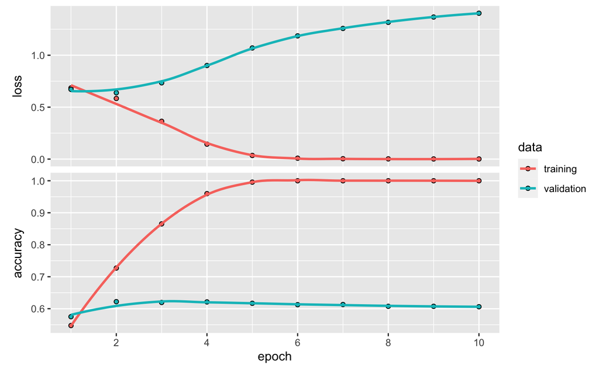

```r
history_rnn %>% plot()
```

The insight of the problem is that `layer_simple_rnn` isn’t good at processing long sequences, such as 500+ words review text. The reason is that words often derive their meaning not only from the one word before, but a longer sequence, eg. the whole sentence in which they occur. For such settings, other types of recurrent layers perform much better. Let’s go on exploring.

## LSTM Application

```r
model_lstm <- keras_model_sequential() %>%
  layer_embedding(input_dim = 10000, output_dim = 32) %>%
  layer_lstm(units = 500, dropout = 0.25, recurrent_dropout = 0.25, return_sequences = FALSE) %>%
  layer_dense(units = 1, activation = "sigmoid")
```

```r
model_lstm %>% compile(
  optimizer = "adam",
  loss = "binary_crossentropy",
  metrics = "accuracy"
)
```

```r
summary(model_lstm)
```

```
Model: "sequential_5"
_________________________________________________________________________________________________
Layer (type)                               Output Shape                           Param #
=================================================================================================
embedding_4 (Embedding)                    (None, None, 32)                       320000
_________________________________________________________________________________________________
lstm (LSTM)                                (None, 500)                            1066000
_________________________________________________________________________________________________
dense_4 (Dense)                            (None, 1)                              501
=================================================================================================
Total params: 1,386,501
Trainable params: 1,386,501
Non-trainable params: 0
_________________________________________________________________________________________________
```

Lets run it!

```r
history_lstm <- model_lstm %>% fit(
  x_train,
  y_train,
  epochs = 5,
  batch_size = 512,
  validation_split = 0.25
  )
```

And lets take a look how the accuracy and loss developed over the epocs.

```r
plot(history_lstm)
```

[output not shown]

In case you have the GPU version of keras installed, you can actually get some real benefits if you use the [`layer_cudnn_gru()`](https://keras.rstudio.com/reference/layer_cudnn_gru.html) instead of the `layer_simple_rnn()`, and the [`layer_cudnn_lstm()`](https://keras.rstudio.com/reference/layer_cudnn_lstm.html) instead of the `layer_lstm`. Both are optimized for CUDA parallel processing on the GPU, and speed up the whole story quite a bit. Both can also be used on colab, since there is the GPU available.

# Endnotes

### References

[^1] Yoshua Bengio, Patrice Simard, and Paolo Frasconi, “Learning Long-Term Dependencies with Gradient Descent Is Difficult,” IEEE Transactions on Neural Networks 5, no. 2 (1994).

[^2] Sepp Hochreiter and Jürgen Schmidhuber, “Long Short-Term Memory,” Neural Computation 9, no. 8 (1997).

### More info

You can find more info about:

- `keras` [here](https://keras.rstudio.com/)